# Low moan detector 2nd generation: data discovery, training, and evaluation

Dan woodrich

2/7/2023

## What is this document?

This is a demonstration of the process to utilize database data and detector outputs for use in data analysis and detector retraining. I am using a tool called RMarkdown, which allows for demonstration of code and plots in a document you can read in your web browser or as a PDF. A similar tool is an online notebook, which lets you run and modify code on the fly, but since this document relies on a personal database connection it should be view only.

The demonstration features 1. Demonstration of database features and built in capabilities 2. Visualization of low moan detector outputs 3. Demonstration for how to select training data using data techniques

## libraries

Below are some libraries which we will call on, as well as an R file which represents the functions from ‘pgpamdb’, which is an R package I am developing to add value to our database.

```r
#install from here:
#install.packages("//nmfs/akc-nmml/CAEP/Acoustics/Matlab Code/Other code/R/pgpamdb/pgpamdb_0.1.11.tar.gz", source = TRUE, #repos=NULL)

library(pgpamdb) #our custom package for routines specific to our database
library(RPostgres) #universal library to connect R session to postgres database
library(ggplot2)
library(scales)

#define a convenince function, which is not included in the pgpamdb package
dbGet <-function(x){
  x = gsub("[\r\n]", "", x)
  dbFetch(dbSendQuery(con,x))
}
```

## Connecting to the database.

The database connection relies on connection to the internet, the NOAA VPN, and several connection variables and keys which we will provide. These are specific to the user, and so are not listed here.

```r
#This populates connection variables for my personal user account to the database.
source("./etc/paths.R")
#Takes the connection variables now in the R session, and uses them to connect to the database with a custom function
con=pgpamdb::pamdbConnect("poc_v2",keyscript,clientkey,clientcert)
```

## What has happened prior to this document?

The low moan detector has been run on a number of AFSC mooring deployments. The reviewed detections from the low moan deployment have been loaded to the database as either true positive or false positive detections. In addition, I uploaded “assumed negative” detections on the timescale of LOW bins (300s). Although each returned detection was reviewed, absence is implied even if no detections were returned for a given segment of time. The assumed negative detections are uploaded as a ‘protocol negative’ type. Entering the assumed negatives as an explicit detection enables us to query from these sections and allows the database to assess assumption conflicts (for example, if there is an assumed negative detection in the same time bin as a verified low moan from another analysis).

In fact, let’s take a glance at the different presence codes: we will use a SQL query to ask the database for the names, and shorthand and integer codes of the labels on the database.

```r
db_labels_explained = dbGet("SELECT name,alias AS shorthand,id FROM label_codes")
knitr::kable(db_labels_explained[order(db_labels_explained$id),],row.names = FALSE)
```

| name | shorthand | id |
| --- | --- | --- |
| no | n | 0 |
| yes | y | 1 |
| maybe | m | 2 |
| no with noise | nn | 4 |
| weak yes | wy | 11 |
| weak maybe | wm | 12 |
| protocol no | pn | 20 |
| protocol yes | py | 21 |
| protocol maybe | pm | 22 |
| logical conflict | lc | 98 |
| unknown | uk | 99 |

In addition to the low moan detector deployment, two accessory analyses were completed and loaded to the database. The first was Cole Watson’s review of ‘positive’ data: data segments containing a verified low moan were presented to Cole for comprehensive boxing. The second was a selection of random data: cole reviewed data selected randomly from each month from 2012 to 2019 over Bering sea moorings.

These additional data sources are valuable additions to a detector retraining.

```r
#Pull out the analyses names, the procedure names, and the procedure ids. This is a high level registry of the low moan analysis effort thus far.
analysis_procedure_names= dbGet("SELECT analyses.name AS analysis_name ,procedures.name AS procedure_name,procedures.id AS procedures_id
                                FROM analyses JOIN procedures ON procedures.analysis_id = analyses.id
                                WHERE analyses.name IN ('Low moan detection','Low moan accessory study')")
knitr::kable(analysis_procedure_names)
```

| analysis_name | procedure_name | procedures_id |
| --- | --- | --- |
| Low moan detection | LM INSTINCT detector first deployment | 5 |
| Low moan detection | LM 2nd gen detector | 21 |
| Low moan detection | LM INSTINCT detector 1st deployment lower threshold test | 22 |
| Low moan accessory study | Low moan random review | 12 |
| Low moan accessory study | Low moan positive review | 13 |

## How to inventory our data?

Before we can start selecting training data, we first need a way to visualize where effort and detections exist for low moans. By analyzing our data in this way, we can better prioritize a wide spatiotemporal distribution for a robust model.

When data are loaded into the database, it automatically updates a table which can be queried to understand the presence and absence of the given signal. Let’s see how low moans effort and presence are distributed across our full dataset.

Let’s use a convenience function from our R package to create a panoptic view of low moans in our data. This creates a heatmap on the month resolution. Gray tiles indicate data exists and is not analyzed, tiles with a black outline indicate that at least one bin contains at least one low moan, and the color scale indicates the % of bins in the month where low moans were present.

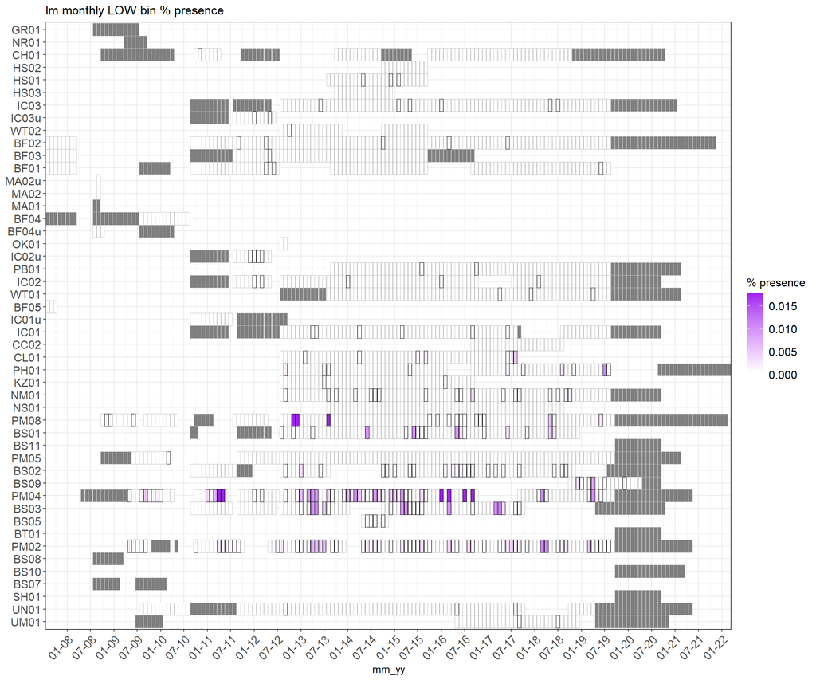

```r
#this is a function which calls queries, some data processing, and ggplot in a set routine. The mooring names are pulled from the database and are ordered by latitude.
lm_map = pgpamdb::bin_label_explore(con,'lm',plot_sds = 2) #plot_sds is standard deviations for the color scale, defaults to 4
plot(lm_map)
```

## Where was the initial training from?

The original LM detector training data was identified by deploying a Raven Band-Limited-Energy-Detector over a few moorings over a few moorings deployments in the area near where the call was originally discovered (Southeastern Bering). The calls and “implied negative” space between the calls were used for detector training.

We can use another function in the pgpamdb package to add a layer onto the heatmap representing this initial sampling presence in a given month.

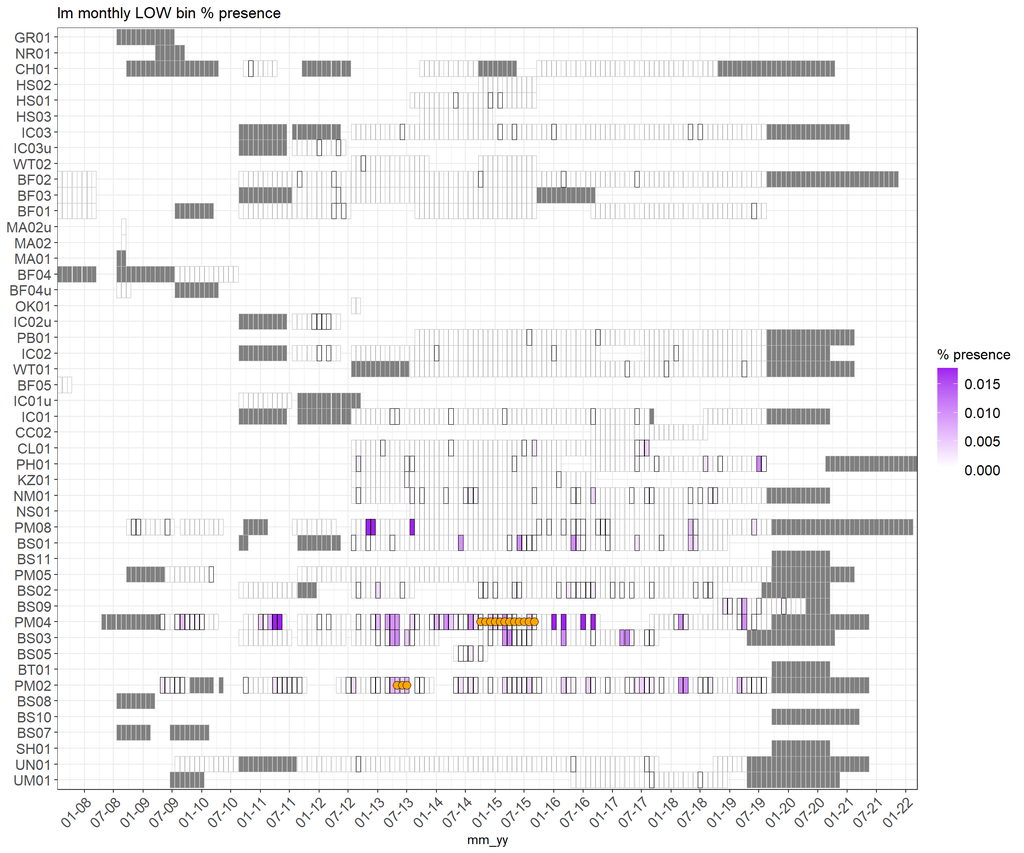

```r
lm_map_w_oggt = lm_map + pgpamdb::add_layer_ble(con,3,10,'orange',c("lm2gen_og_train"))
plot(lm_map_w_oggt)
```

As discovery of these initial calls were opportunistic, we can see that this a limited sampling in space and time of where we now know low moans to be distributed throughout our data.

## What can we learn from the accessory studies?

Knowing the utility for future training, the accessory studies of the “Low moan negative review” and “Low moan positive review” were annotated with an implied negative assumption.

These studies both sampled over a wide spatial and temporal range, but differ in what they provide to retraining. The Low moan positive review’s protocol focused on effort where low moans were detected and verified, meaning that it is rich in true positive detections while limited in total effort time. The negative review did not use detector outputs, so the stratified sample covered a wide range of space, time and conditions, and any low moans encountered in this review were randomly identified and not biased in any way towards detector performance. This sample is rich in time, while poor in detections. Roughly speaking, the positive study provides value to the retraining process for the positives it contributes, while the random study provides value in contribution of negative instances.

Let’s compare these attributes using SQL queries to the database.

```r
#effort time by study
effort_count = dbGet("SELECT SUM(seg_end-seg_start)/3600 AS effort_hours,effort.name
                     FROM bins JOIN bins_effort ON bins.id = bins_effort.bins_id JOIN effort ON bins_effort.effort_id = effort.id
                     WHERE effort.name IN ('LMyesSample_1','oneHRonePerc') GROUP BY effort.name")

effort_count$effort_hours = as.integer(effort_count$effort_hours)

effort_count$name[which(effort_count$name=="LMyesSample_1")]= 'positive'
effort_count$name[which(effort_count$name=="oneHRonePerc")]= 'random'

#count of total lm's boxed by cole in each study
lms_count = dbGet("SELECT COUNT(*),procedures.name FROM detections JOIN procedures ON detections.procedure = procedures.id
                  WHERE procedures.name IN ('Low moan random review','Low moan positive review') AND label =1 GROUP BY procedures.name")

#create table
studies_table = data.frame(lms_count$name,effort_count$effort_hours,lms_count$count)
colnames(studies_table) = c("study name","effort hours","total low moans")

knitr::kable(studies_table)
```

| study name | effort hours | total low moans |
| --- | --- | --- |
| Low moan positive review | 110 | 3612 |
| Low moan random review | 1217 | 205 |

Let’s take a quick look at trends comparison to better understand these studies. What is the temporal distribution of verified low moans, comparing the detector-biased positive review vs the random review?

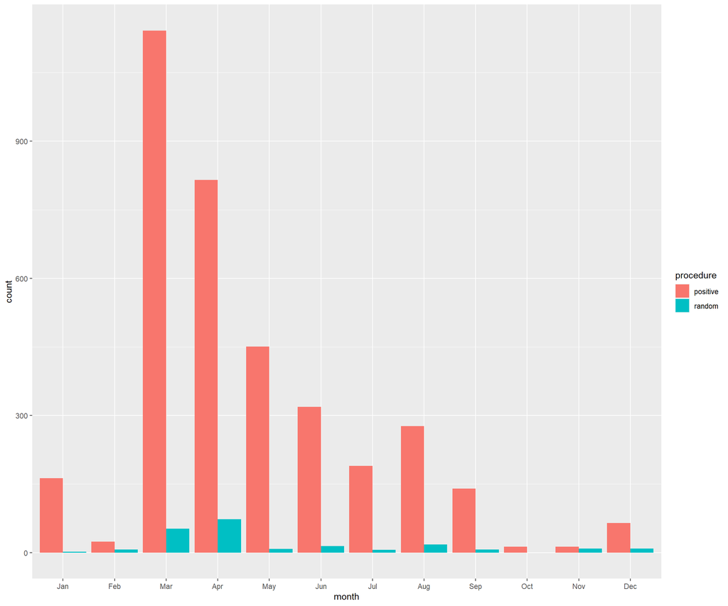

```r
datetotals = dbGet("SELECT EXTRACT(MONTH FROM date_trunc('month', soundfiles.datetime)) AS month,procedure,COUNT(*)
                   FROM detections JOIN soundfiles ON detections.start_file = soundfiles.id
                   WHERE detections.procedure IN (12,13) AND label = 1 GROUP BY month,procedure")

#data formatting for prettier plotting
datetotals$procedure = as.character(datetotals$procedure)
datetotals[which(datetotals$procedure==12),"procedure"]= "random"
datetotals[which(datetotals$procedure==13),"procedure"]= "positive"
datetotals$count = as.integer(datetotals$count)

datetotals$procedure = as.factor(datetotals$procedure)
datetotals$month = factor(month.abb[datetotals$month],levels = month.abb)

#add a 0 not present in the query
missingmonth = data.frame('Oct','random',0)
colnames(missingmonth) = colnames(datetotals)
datetotals = rbind(datetotals,missingmonth)

seasoncompare = ggplot(datetotals, aes(month, count, fill=procedure))+ geom_bar(stat = "identity", position = 'dodge')
plot(seasoncompare)
```

We see there is fairly good agreement between the two sampling methods on when low moans occur, with some caveat of the small sample size of the confirmed low moans in the random sample.

Another question we might ask about these studies is: what is the spatiotemporal distribution of the accessory studes? And what spatiotemporal and procedural gaps remain?

Let’s look at each of these samples on our spatiotemporal map, starting with the negative sample.

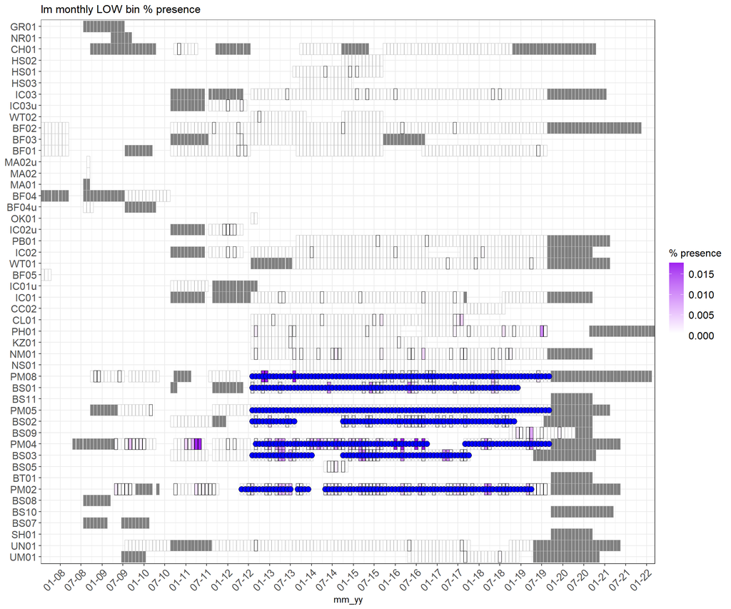

```r
lm_map_neg_samp = lm_map + pgpamdb::add_layer_ble(con,3,12,'blue',c("oneHRonePerc"))
plot(lm_map_neg_samp)
```

By procedure, the sample was from Bering moorings M2, M4, BS3, BS4, BS2, M5, BS1, and M8. It was stratified to sample from each month to ensure even coverage, and we can observe that it succeeded in achieving wide spatiotemporal coverage in the Bering Sea.

Let’s take a look at the positive sample.

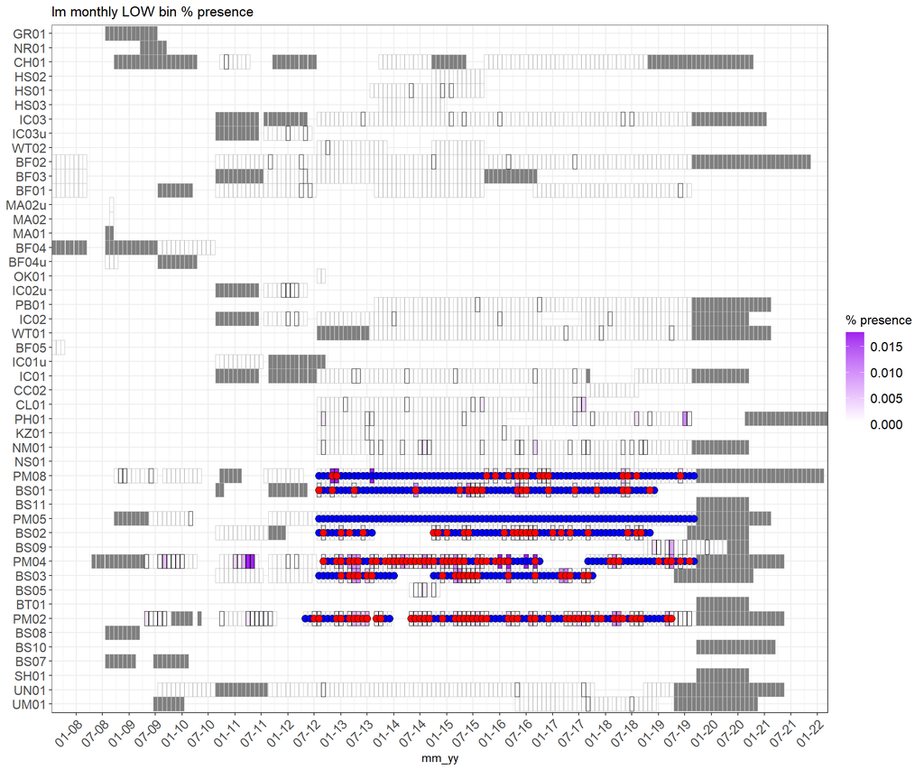

```r
lm_map_pos_samp = lm_map_neg_samp + pgpamdb::add_layer_ble(con,3,13,'red',c("LMyesSample_1"))
plot(lm_map_pos_samp)
```

This sample covers where we had previously confirmed the presence of low moans, and so it clusters around where low moans were detected in higher number.

All together, we could interpret these studies as good contributions for Bering Sea data to the 2nd generation model. From a spatial standpoint, we clearly lack training data from the higher latitudes, despite seeing verified low moans in these locations.

## Creating training versions of our data sources

As we can see, there is a considerable amount of potential overlap between the original, positive review and random review data sources.

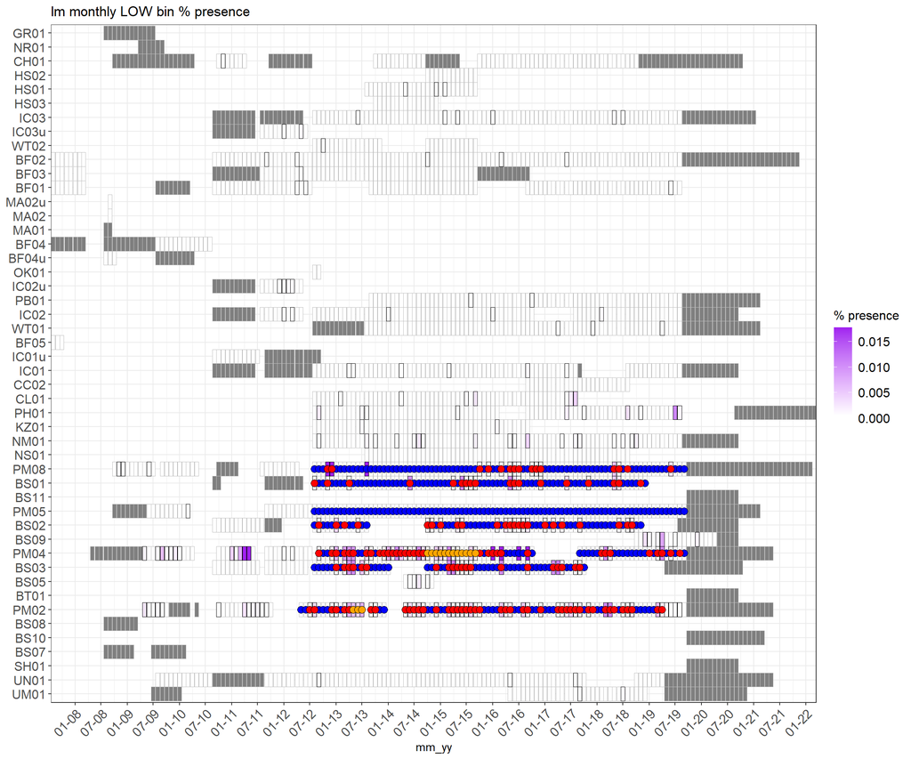

```r
lm_map_all3_samp = lm_map + pgpamdb::add_layer_ble(con,3,12,'blue',c("oneHRonePerc")) + pgpamdb::add_layer_ble(con,3,13,'red',c("LMyesSample_1")) + pgpamdb::add_layer_ble(con,3,10,'orange',c("lm2gen_og_train"))
plot(lm_map_all3_samp)
```

To turn the existing data sources into suitable training samples, and to create new training samples we will have to make sure to create versions of them where effort does not overlap to prevent duplicate data being fed to the model, which is problematic for training and evaluation statistics.

The database contains a table of ‘bins’, which are png-sized (300s,225s,90s) splits of our data which compose effort for use with different samples. To avoid overlap, we have to identify the duplicate bins between samples, and remove duplicates to create a special training sample.

It does not matter which sample we remove the duplicates from, since the data will be equally considered by the training process. If boxes from multiple studies are refer to the same call between samples, the training process will take the union of the detection pool to not double count individual calls.

First, we select the bin ids (unique identifier) which compose the original training.

```r
lm2gen_og_train = dbGet("SELECT bins_id FROM bins_effort JOIN effort ON bins_effort.effort_id = effort.id
                        WHERE effort.name = 'lm2gen_og_train'")

lm2gen_og_train = as.integer(lm2gen_og_train$bins_id)
```

Then, we load in the positive review sample

```r
lm2gen_train_pos_set_no_ovlp = dbGet("SELECT bins_id FROM bins_effort JOIN effort ON bins_effort.effort_id = effort.id
                                     WHERE effort.name = 'LMyesSample_1'")

lm2gen_train_pos_set_no_ovlp = as.integer(lm2gen_train_pos_set_no_ovlp$bins_id)
```

To create the training version, we select only the bins which are not in the previous sample.

```r
lm2gen_train_pos_set_no_ovlp = lm2gen_train_pos_set_no_ovlp[-which(lm2gen_train_pos_set_no_ovlp %in% lm2gen_og_train)]
```

Similarly, for the random review sample, we exclude duplicate bins from both the original and positive review samples.

```r
lm2gen_train_rand_set_no_ovlp = dbGet("SELECT bins_id FROM bins_effort JOIN effort ON bins_effort.effort_id = effort.id
                                      WHERE effort.name = 'oneHRonePerc'")

lm2gen_train_rand_set_no_ovlp = as.integer(lm2gen_train_rand_set_no_ovlp$bins_id)

lm2gen_train_rand_set_no_ovlp = lm2gen_train_rand_set_no_ovlp[-which(lm2gen_train_rand_set_no_ovlp %in% c(lm2gen_train_pos_set_no_ovlp,lm2gen_og_train))]
```

## Creating hard negative sample

Common good practice for model training is to include ‘hard negatives’ - false positives with high probability. These detections help the model handle the tough distinctions between the signal and similar noise, which can improve performance considerably. Along with the next sample we will introduce, although these cover data which were run by the detector, they will be reviewed with the ‘implied negative’ assumption which does not apply to detector outputs but is necessary for retraining.

To create our hard negative sample, we first have to decide: 1. How much data do we want? 2. What probability cutoff constitutes a hard negative? 3. Do we want to sample within a wider range of probabilities or choose a higher cutoff?

How much data would we like for our sample? At a minumum, it should be in the neighborhood of the size of our other samples. However, since the other samples were larger and more dedicated efforts, these samples will be comparitively smaller due to time restrictions. So, perhaps 1/2 the size of the smallest sample would be a good floor to be a relevant contributor to the training process, so something like 650 300s bins (~50 hours). If we are struggling to acheive good results in training, we could sample from within the larger segments as well to promote the hard negatives.

Now that we know the amount of data we want, we can decide how we would like to define our hard negatives. There are two approaches we could take: take a cutoff to match the amount of data we want, or take a cutoff which matches the range of what we consider a hard negative, and sample from within that range.

Let’s take a look at how the probabilities distribute in our real data:

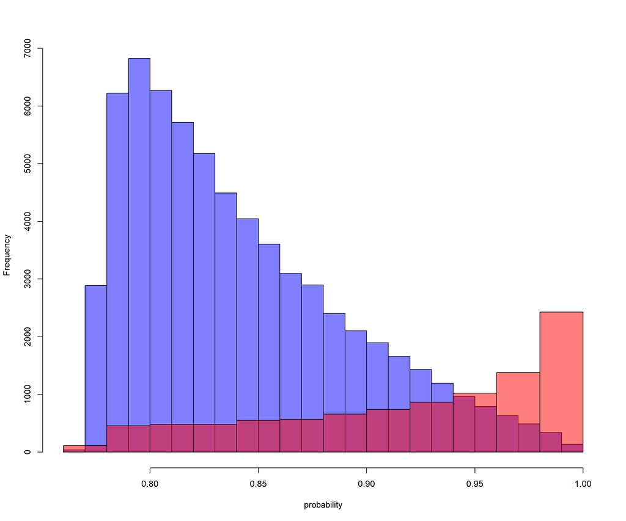

```r
lm_allprobs = dbGet("SELECT probability,label FROM detections
                    JOIN procedures ON detections.procedure = procedures.id
                    WHERE procedures.name = 'LM INSTINCT detector first deployment' AND probability IS NOT NULL")

#view relationship

#histogram (blue) of false positive probabilities
hist(lm_allprobs$probability[which(lm_allprobs$label==0)],col=rgb(0,0,1,1/2),xlab = "probability",main= NULL)
#histogram (red) of true positive probabilities
hist(lm_allprobs$probability[which(lm_allprobs$label==1)],col=rgb(1,0,0,1/2),add=TRUE)
```

Based on this graphic, I like the cutoff of .95 - around this probability the positives start to become more frequent in number to the negatives, making the negatives particularly eggregious. I personally like choosing a lower cutoff for hard negatives and sampling within this pool than choosing all instances in an ultra-high cutoff (for example, > .99). The reason being is that in my experience over several different detectors and applications, ultra-high cutoffs tend to comprise a fairly non-diverse pool of false positives, as one or two types of recoccuring patterns tend to dominate.

Choosing the arbitrary cutoff of .95 will mean that we may have to further sample if it is too large. Let’s check:

```r
lm2gen_hardneg =dbGet("SELECT DISTINCT bins.id FROM bins JOIN bins_detections ON bins_detections.bins_id = bins.id JOIN
                      detections ON bins_detections.detections_id = detections.id JOIN procedures ON detections.procedure =
                      procedures.id
                      WHERE procedures.name = 'LM INSTINCT detector first deployment' AND bins.type = 1 AND detections.label = 0 AND detections.probability >= .95")

lm2gen_hardneg = as.integer(lm2gen_hardneg$id)

#remove duplicates:

lm2gen_hardneg = lm2gen_hardneg[-which(lm2gen_hardneg %in% c(lm2gen_train_rand_set_no_ovlp,lm2gen_train_pos_set_no_ovlp,lm2gen_og_train))]


print(length(lm2gen_hardneg))
```

```
## [1] 1974
```

This is too large (our target for time management was 650 bins), so we will take a third of it

```r
lm2gen_hardneg_ds = sample(lm2gen_hardneg,round(length(lm2gen_hardneg)/3))
print(length(lm2gen_hardneg_ds))
```

```
## [1] 658
```

Later, we’ll show how this sample distributes throughout the data along with another sample we will create for this retraining.

## Odd positives

We noted earlier that the spatial distribution of our training data was heavily biased towards the Bering- while the addition of hard negatives will help expand our training set spatially, we should also attempt to integrate more data from the higher latitudes with a strategic sample. As before, these data were previously run but will now be reviewed with implied negative assumption (data manually reviewed with every call boxed).

For the last data source, I decided to pull ‘odd positives’- sort of the logical reversal of hard negatives. Instead of likely (high probability) detections that were marked no, odd positives will be the “unlikely” detections that were marked as yes. Since the detector review protocol will not return low probability detections, unlikelyness will be determined with spatial criteria as opposed to probability. Our spatial criteria will only consider mooring locations where only a small amount of low moans were detected, treating our moorings with many detections as outliers for the sample.

What mooring locations are more or less likely to contain low moans?

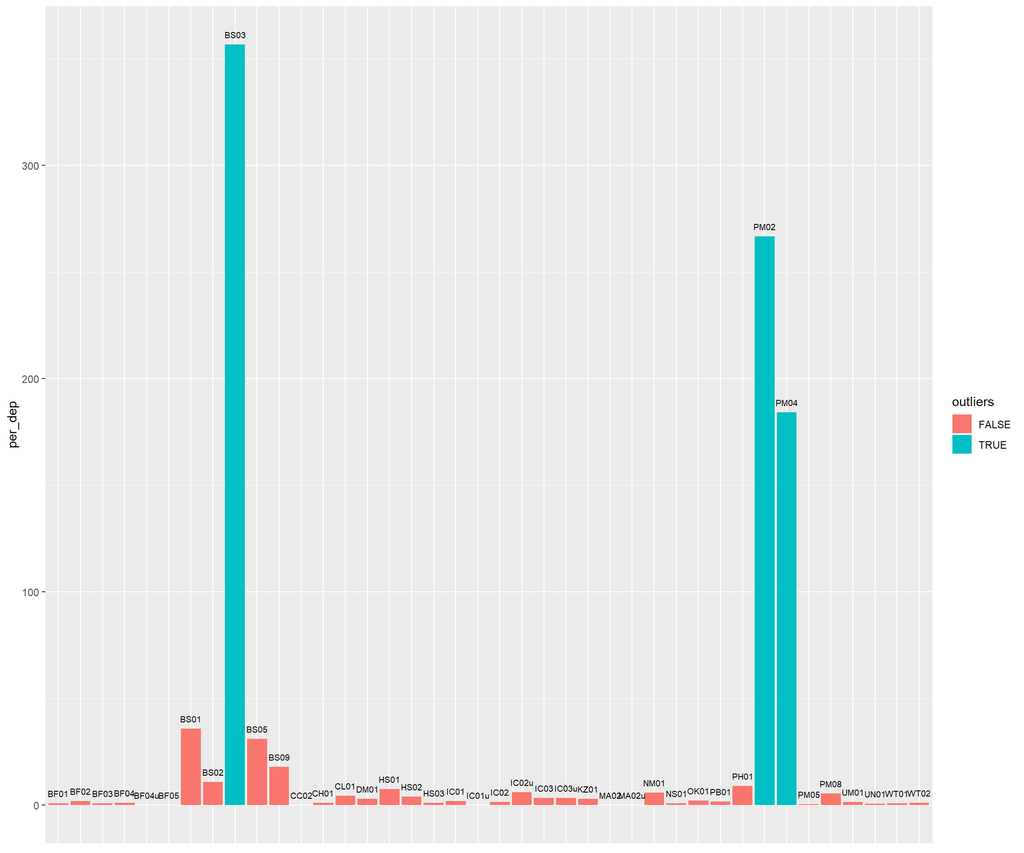

```r
tp_rate = dbGet("SELECT location_code, COUNT(CASE WHEN label = 1 THEN 1 END) AS tp,
                 COUNT(CASE WHEN label = 0 THEN 1 END) AS fp,
                 COUNT(DISTINCT(data_collection.name)) AS dep_num
                 FROM detections JOIN soundfiles
                 ON detections.start_file = soundfiles.id JOIN data_collection ON
                 data_collection.id = soundfiles.data_collection_id JOIN procedures ON detections.procedure = procedures.id
                 WHERE procedures.name = 'LM INSTINCT detector first deployment' GROUP BY location_code")

tp_rate$rate = tp_rate$tp/(tp_rate$tp + tp_rate$fp)

tp_rate$per_dep = tp_rate$tp/tp_rate$dep_num

#arbitrary cutoff looking at the per deployment counts in the data- considering outliers where
#per deployment counts exceed 100 for the original detector deployment.
tp_rate$outliers = tp_rate$per_dep > 100

ggplot(tp_rate, aes(x=location_code,y=per_dep,fill = outliers))+ geom_bar(stat="identity") +
   geom_text(aes(x = location_code, y = per_dep, label = location_code),
            size = 2.5,
            position = position_dodge(.9),
            inherit.aes = TRUE,
            na.rm = TRUE, vjust = -1) +  theme(axis.title.x=element_blank(),
        axis.text.x=element_blank(),
        axis.ticks.x=element_blank())
```

There are three outliers among the mooring sites: M2, BS3, and M4. So, these will be the exluded from the odd_tp sample.

Now, we can pull the sample:

```r
lm2gen_oddtp = dbGet(
  "SELECT DISTINCT bins.id FROM detections JOIN bins_detections ON bins_detections.detections_id = detections.id
  JOIN bins ON bins.id = bins_detections.bins_id JOIN soundfiles ON bins.soundfiles_id = soundfiles.id JOIN
  data_collection ON data_collection.id = soundfiles.data_collection_id
  WHERE bins.type = 1 AND detections.procedure = 5 AND
  detections.label = 1 AND data_collection.location_code NOT IN ('BS03','PM02','PM04')"
)

lm2gen_oddtp = as.integer(lm2gen_oddtp$id)

#remove duplicates:

lm2gen_oddtp = lm2gen_oddtp[-which(lm2gen_oddtp %in% c(lm2gen_og_train,lm2gen_train_pos_set_no_ovlp,lm2gen_train_rand_set_no_ovlp,lm2gen_hardneg_ds))]
```

Let’s see how the size compares:

```r
print(length(lm2gen_oddtp))
```

```
## [1] 392
```

Since this is fewer bins than the other data soures, we shouldn’t additionally sample it but include it as is.

Now that we have our new training samples, let’s compare how they stack up compare to the first detector sample in terms of spatiotemporal coverage. This is the total training coverage of the new sample, with combined effort in cyan:

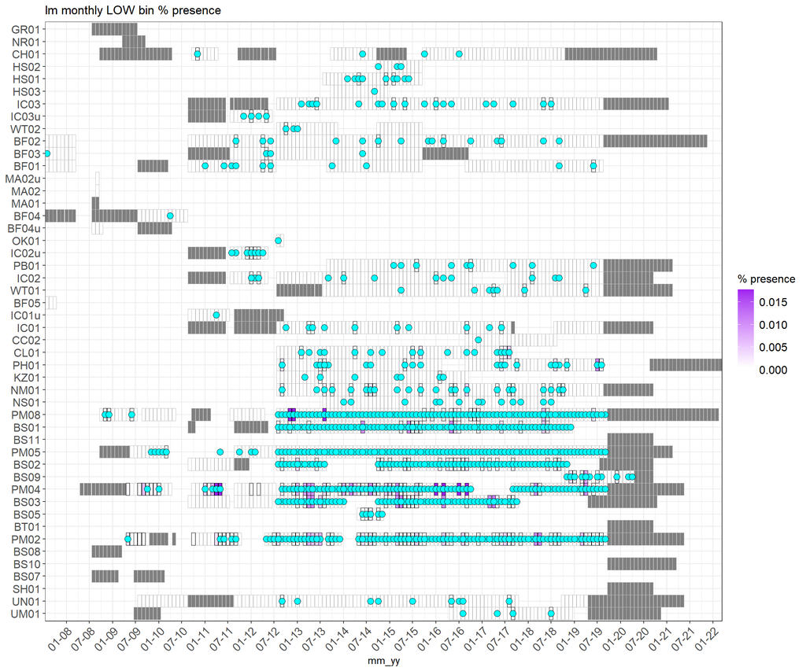

```r
lm_map_LM2gen = lm_map + pgpamdb::add_layer_ble(con,3,10,'cyan',c("lm2gen_og_train")) + pgpamdb::add_layer_ble(con,3,13,'cyan',c("lm2gen_train_pos_set_no_ovlp")) + pgpamdb::add_layer_ble(con,3,12,'cyan',c("lm2gen_train_rand_set_no_ovlp"))+ pgpamdb::add_layer_ble(con,3,10,'cyan',c("lm2gen_hardneg_ds")) + pgpamdb::add_layer_ble(con,3,10,'cyan',c("lm2gen_oddtp"))
plot(lm_map_LM2gen)
```

This is the same map, with the first detector training coverage superimposed in orange:

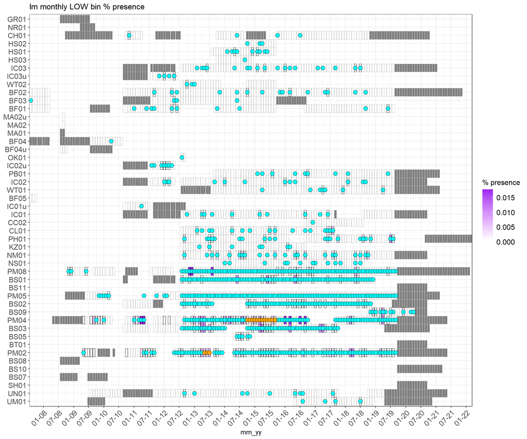

```r
lm_map_LM2gen_wog = lm_map_LM2gen + pgpamdb::add_layer_ble(con,3,10,'orange',c("lm2gen_og_train"))
plot(lm_map_LM2gen_wog)
```

## Second generation detector training and evaluation.

Outside of this Rmarkdown, I manually annotated signals in the hard negative and oddtp set, and integrated all of the samples into training. The tool I used for annotation was a pipeline in INSTINCT (EditGTpublish) which pulls the effort from the database, pairs it with the associated soundfiles, loads a the data into Raven pro for analysis, and uploads the edited data to the database. INSTINCT is not easy to showcase here as it is a standalone application, not a package you can use in R or python. Here is a screenshot of the manual annotation process while in Raven.

[figure not shown]

```r
#file from a seperate process
plot(raven_screen, axes=FALSE, ann=FALSE)
```

Once the new effort samples had been comprehensively boxed, I ran the model, which again happened outside of this Rmarkdown. The result was a high quality detector, known as the second generation low moan detector. Here are some of the artifacts of the model training process. First, here is a precision-recall curve of the trained detector applied to the training and validation data. A precision-recall curve plots the precision (of detections, the proportion of true positive to false positive detections) vs recall (proportion of true positives returned vs the total available pool of true positives). The lines vs dots are two ways of calculating the statistics which should be in fairly close agreement.

One important thing to note about prCurves and their associated AUC is that they are strongly influenced by the composition of the training data, and so detector performance can’t be compared across training sets. Performance should be judged relative to prior performance statistics on the same training set, making sure to also compare performance qualitatively on real data.

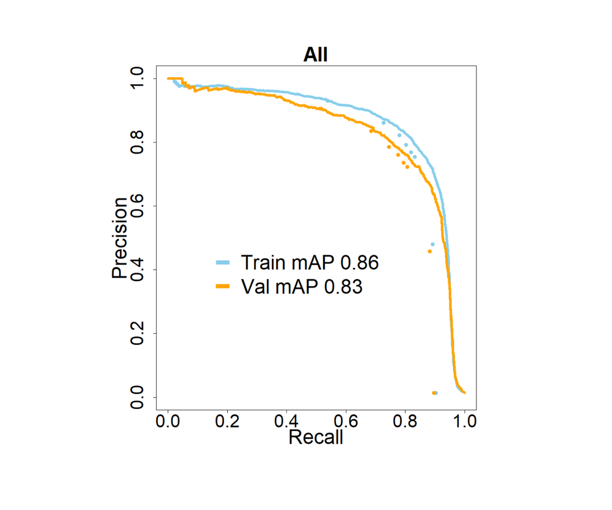

```r
#file from a seperate process
plot(prcurve, axes=FALSE, ann=FALSE)
```

An important consideration for statistical interpretation of this model’s performance is that selection of data which can improve the performance of the model may also have the effect of driving down performance statistics. The inclusion of a very large dataset (“negative sample”) which contained few low moans will drive down the precision statistics (more time = more false positives). Another example of this is selection of high SNR data, as well as hard negatives- this will provide the model with extremely useful examples for the hardest cases it will face, but at the same time will decrease performance statistics as these instances will be more frequently missed.

Keep in mind when selecting data that trying to cater to performance statistics too strongly may end up weakening your model, so even if it helps the paper get published, it may be working against you.

Alternate stastics can also be employed to highlight important aspects of the training set. For instance, plotting false positives per hour vs recall stands up better to datasets with more sparse instances of the target signal.

Here are other statistics that are exported from the model run:

```r
stats = read.csv("//akc0ss-n086/NMML_CAEP_Acoustics/Detector/Datasets_transfer/501729/Model_Stats_Train_Stats.csv")
stats_0.9c = stats[which(stats$cutoff_==0.9),]

#get rid of some in the weeds/ less used stats by removing certain columns
stats_0.9c = stats_0.9c[,-c(13,14)]



knitr::kable(stats_0.9c)
```

|  | FGID | split | detTotal | numTPtruth | numTP | numTPout | numFP | numFN | cutoff_ | Recall | Precision | F1 | EffortHours | TPperHour | TPdetperHour | FPperHours | numFNperHour |
| --- | --- | --- | --- | --- | --- | --- | --- | --- | --- | --- | --- | --- | --- | --- | --- | --- | --- |
| 8 | all | 1 | 3866 | 3732 | 2911 | 3179 | 687 | 821 | 0.9 | 0.7800107 | 0.8222969 | 0.8005958 | 1132.736042 | 3.2946775 | 2.5698838 | 0.6064961 | 0.7247937 |
| 17 | all | 2 | 1276 | 1257 | 937 | 1002 | 274 | 320 | 0.9 | 0.7454256 | 0.7852665 | 0.7648275 | 377.578681 | 3.3291075 | 2.4816020 | 0.7256766 | 0.8475055 |
| 22 | lm2gen_train_pos_set_no_olvp | 1 | 2166 | 2166 | 1777 | 1973 | 193 | 389 | 0.9 | 0.8204063 | 0.9108957 | 0.8632862 | 78.187500 | 27.7026379 | 22.7274181 | 2.4684253 | 4.9752198 |
| 31 | lm2gen_train_pos_set_no_olvp | 2 | 700 | 741 | 574 | 621 | 79 | 167 | 0.9 | 0.7746289 | 0.8871429 | 0.8270769 | 26.062500 | 28.4316547 | 22.0239808 | 3.0311751 | 6.4076739 |
| 43 | lm2gen_train_rand_set_no_ovlp | 1 | 109 | 83 | 45 | 46 | 63 | 38 | 0.9 | 0.5421687 | 0.4220183 | 0.4746074 | 910.062500 | 0.0912025 | 0.0494472 | 0.0692260 | 0.0417554 |
| 52 | lm2gen_train_rand_set_no_ovlp | 2 | 37 | 30 | 7 | 10 | 27 | 23 | 0.9 | 0.2333333 | 0.2702703 | 0.2504472 | 303.354167 | 0.0988943 | 0.0230753 | 0.0890049 | 0.0758190 |
| 57 | lm2gen_oddtp | 1 | 339 | 308 | 225 | 250 | 89 | 83 | 0.9 | 0.7305195 | 0.7374631 | 0.7339749 | 24.412083 | 12.6167028 | 9.2167472 | 3.6457355 | 3.3999556 |
| 66 | lm2gen_oddtp | 2 | 110 | 98 | 67 | 70 | 40 | 31 | 0.9 | 0.6836735 | 0.6363636 | 0.6591708 | 8.137361 | 12.0432163 | 8.2336275 | 4.9155985 | 3.8095888 |
| 80 | lm2gen_og_train | 1 | 854 | 821 | 594 | 641 | 213 | 227 | 0.9 | 0.7235079 | 0.7505855 | 0.7367980 | 79.750000 | 10.2946708 | 7.4482759 | 2.6708464 | 2.8463950 |
| 89 | lm2gen_og_train | 2 | 298 | 285 | 211 | 222 | 76 | 74 | 0.9 | 0.7403509 | 0.7449664 | 0.7426515 | 26.583333 | 10.7210031 | 7.9373041 | 2.8589342 | 2.7836991 |
| 95 | lm2gen_hardneg_ds | 1 | 398 | 354 | 270 | 269 | 129 | 84 | 0.9 | 0.7627119 | 0.6758794 | 0.7166751 | 40.323958 | 8.7789001 | 6.6957712 | 3.1990907 | 2.0831288 |
| 104 | lm2gen_hardneg_ds | 2 | 131 | 103 | 78 | 79 | 52 | 25 | 0.9 | 0.7572816 | 0.6030534 | 0.6714247 | 13.441319 | 7.6629382 | 5.8030017 | 3.8686678 | 1.8599365 |

Less than 1 FP/hour are necessary to acheive a recall of ~75% on the test set. These are good numbers: 12 fp/hour is often (completely arbitrarily) touted in the community as a resonable amount of FP/hour for review.

To evaluate this model in a real world example, I deployed it on the moorings BS13_AU_04b, which Cole had previously reviewed on a very low probability cutoff in the first model deployment to use as a future performance comparison. The very low cutoff represented a cutoff which would enable discovery of more tps, but was unrealistic to scale the analysis across our data. It was selected based on what we knew about his pace to ensure a fairly comprehensive analysis in a multi-week period.

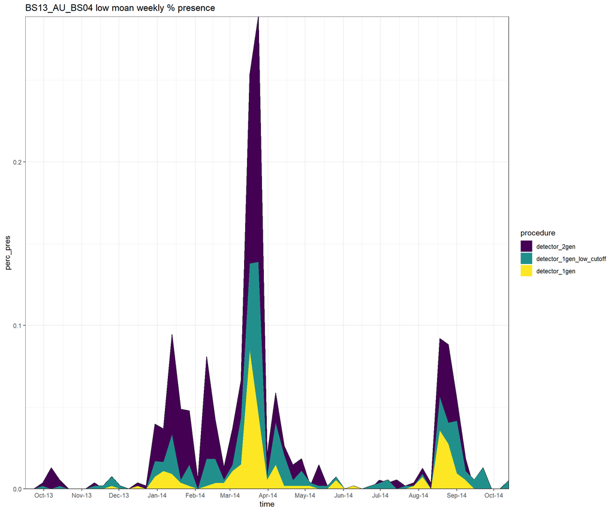

```r
#get the weekly % presence. This gquery ets yes bins per time for procedures 5, 21, and 22

per_time_y_bins_q = "SELECT DISTINCT ON (subquery.time,subquery.procedure) subquery.time,subquery.procedure,COUNT(*) FROM
(SELECT DISTINCT ON (time,procedure,bins.id) date_trunc('week', soundfiles.datetime) AS time,COUNT(*),procedure,bins.id
FROM detections JOIN bins_detections ON detections.id = bins_detections.detections_id JOIN bins ON bins_detections.bins_id = bins.id JOIN soundfiles ON soundfiles.id = bins.soundfiles_id JOIN data_collection ON data_collection.id = soundfiles.data_collection_id
WHERE data_collection.name = 'BS13_AU_PM04' AND detections.label = 1 AND detections.procedure IN (5,21,22) AND bins.type = 1 GROUP by time,procedure,bins.id) AS subquery
GROUP by time,procedure"

output = dbGet(per_time_y_bins_q)
output$count = as.integer(output$count)

#now query for all bins (regardless of y or n) per week

per_time_all_q = "SELECT COUNT(*),date_trunc('week', soundfiles.datetime) AS time
FROM bins JOIN soundfiles ON bins.soundfiles_id = soundfiles.id JOIN data_collection ON data_collection.id = soundfiles.data_collection_id
WHERE data_collection.name = 'BS13_AU_PM04' AND bins.type = 1
GROUP by time"

#merge queries into single table
all_bins = dbGet(per_time_all_q)
all_bins$count = as.integer(all_bins$count)
colnames(all_bins)[1]="total_bins"

alltimes5 = merge(output[which(output$procedure==5),],all_bins,all.y = TRUE)
alltimes5$procedure=5
alltimes21= merge(output[which(output$procedure==21),],all_bins,all.y = TRUE)
alltimes21$procedure=21
alltimes22 = merge(output[which(output$procedure==22),],all_bins,all.y = TRUE)
alltimes22$procedure=22

alltimes = rbind(alltimes5,alltimes21,alltimes22)

#calculate percent presence per week
alltimes[which(is.na(alltimes$count)),"count"]=0
alltimes$perc_pres = alltimes$count/alltimes$total_bins

#format table for prettier plotting
alltimes$procedure = as.character(alltimes$procedure)
alltimes$procedure[which(alltimes$procedure=="5")]="detector_1gen"
alltimes$procedure[which(alltimes$procedure=="22")]="detector_1gen_low_cutoff"
alltimes$procedure[which(alltimes$procedure=="21")]="detector_2gen"
alltimes$procedure = factor(alltimes$procedure,levels = c("detector_2gen","detector_1gen_low_cutoff","detector_1gen"))

out = ggplot(data=alltimes,colour="black", aes(x=time, y=perc_pres, fill = procedure)) +
  geom_line() +
geom_area(position="identity") +
        scale_x_datetime(date_breaks = "1 month", date_labels = "%b-%y",expand=c(0,0)) +
        scale_y_continuous(expand=c(0,0)) +
        ggtitle("BS13_AU_BS04 low moan weekly % presence") +
        theme_bw() +
  scale_color_viridis_d(aesthetics = "fill")


plot(out)
```

While the lower cutoff on the original detector is clearly an improvement from the original detector and cutoff, the 2nd gen model reveals even more presence that would have previously been missed. However, positive presence isn’t the whole story- let’s compare these three approaches by the amount of false positives per procedure.

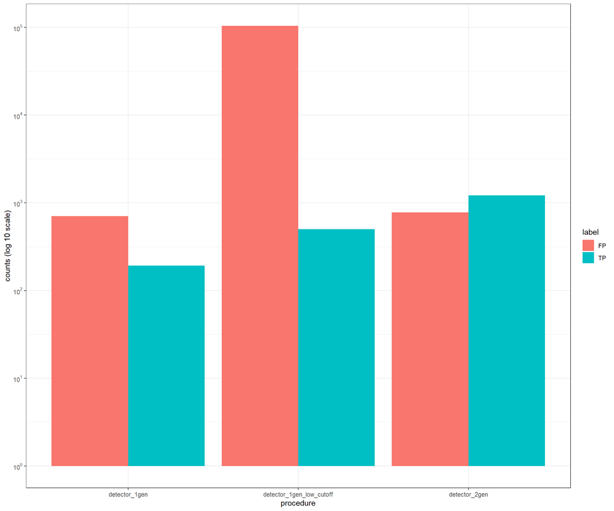

```r
tp_fp_proc = "SELECT COUNT(*),procedure,label FROM detections JOIN soundfiles ON detections.start_file = soundfiles.id JOIN data_collection ON data_collection.id = soundfiles.data_collection_id
WHERE label IN (1,0) AND procedure IN (5,21,22) AND data_collection.name = 'BS13_AU_PM04' GROUP by label,procedure"

#format data for prettier plotting
tp_fp_out = dbGet(tp_fp_proc)
tp_fp_out$count = as.integer(tp_fp_out$count)
tp_fp_out$count_log = log(tp_fp_out$count)
tp_fp_out$procedure = as.character(tp_fp_out$procedure)
tp_fp_out$procedure[which(tp_fp_out$procedure=="5")]="detector_1gen"
tp_fp_out$procedure[which(tp_fp_out$procedure=="22")]="detector_1gen_low_cutoff"
tp_fp_out$procedure[which(tp_fp_out$procedure=="21")]="detector_2gen"
tp_fp_out$procedure = factor(tp_fp_out$procedure,levels = rev(c("detector_2gen","detector_1gen_low_cutoff","detector_1gen")))
tp_fp_out$label= as.character(tp_fp_out$label)
tp_fp_out$label[which(tp_fp_out$label==1)]="TP"
tp_fp_out$label[which(tp_fp_out$label==0)]="FP"

g <- ggplot(tp_fp_out, aes(x=procedure,y=count,fill = label))+ geom_bar(stat = "identity", position="dodge") +
  theme_bw() +
    scale_y_continuous(trans='log10',
                     breaks=trans_breaks('log10', function(x) 10^x),
                     labels=trans_format('log10', math_format(10^.x)))+
  ylab("counts (log 10 scale)")

plot(g)
```

Comparing the detectors side by side, we can see that the performance of the 2nd gen detector is superior to both configurations of the first detector, both in quantity of true positives and the ratio of true positives to false positives. This is especially impressive, considering that the low cutoff detector generated fewer true positives than the second generation model but that the rate of false positives was completely infeasible for review for the low cutoff 1st gen detector, while the rate of false positives was roughly the same between the 1st (normal cutoff) and 2nd generation low moan detectors.

Consider as well that not all false positives are created equal. While the detector_1gen_low_cutoff was a three-week, excruciating exercise in monotony (Thanks Cole!) the detector_2gen false positives were largely arguable, or returned signals which while incorrect should be returned in review due to their similarity and reliance on contextual features unavailable to the detector.

Quantitatively and qualitatively we were able to use multiple rounds of detector development to produce a high quality, second generation low moan detector. Further tuning to a more selective criteria is always possible through more rounds of label review.

Thanks for the read! -Dan